# Power analysis

```r
library(dplyr)
```

```r
library(ggplot2)
library(rstatix)
load("~/Dropbox (University of Oregon)/UO-SAN Lab/Berkman Lab/Devaluation/analysis_files/data/scored_data.RData")

scored$score <- as.numeric(scored$score)
```

```r
#
scored %>% filter(scale_name %in% c("FCI")) %>% select(scored_scale) %>% unique
```

|  | scored_scale |
| --- | --- |
| 1 | cancer_preventing |
| 193 | cancer_promoting |
| 385 | craved_cancer_preventing |
| 577 | craved_cancer_promoting |
| 769 | dairy |
| 961 | empty_calories |
| 1153 | fried_food |
| 1345 | fruit |
| 1537 | grains |
| 1729 | liked_cancer_preventing |

[output cut: 7 more lines]

```r
scored$scale_name %>% unique
```

```
##  [1] "MESA_HealthyFood" "BFI"              "BSCS"             "NCS"
##  [5] "PLAN"             "BIS-11"           "EDM"              "FCI"
##  [9] "FFQ"              "ACES"             "IMI"
```

Now get BMI

```r
load("../../../files/data/ppt_list_w_data.RData")
#our primary health outcome measure
ppt_pct_body_fat <- ppt_list_w_data %>% select(dev_id,bf_1) %>% filter(!is.na(bf_1))
ppt_bmi <- ppt_list_w_data %>% select(dev_id,bmi_0) %>% filter(!is.na(bmi_0))
rm(ppt_list_w_data)
```

## Health measures include:

- Percent Body Fat (`bf_1`)
- BMI (`bmi_0`)

## Behavioral outcome measures

We also have behavioral outcome measures:

- Food Frequency Questionnaire. Very closely related to the Food Craving Inventory so that needs to be considered carefully.

## Self-report predictor variables to investigate

Which predictor scales should we include?

Need the behavioral and self-report imho

Before we decide which to include, perhaps we put them into categories: obvious theoretical link to outcome (3), possible theoretical link to outcome (2), no clear theoretical link to outcome (1).

Listing them by these categories we get:

### Obvious theoretical link to outcome

These are explicitly designed to measure constructs we are concerned about, like self control or habits.

- Brief Self Control Scale
- Self-reported Habit Index
- Tempest Self-Regulation Questionnaire for Eating
- Treatment Self-Regulation Questionnaire
- Barratt Impulsiveness Scale
- Eating Dysregulation Measure
- Food Craving Inventory
- Restraint Scale

### Possible theoretical link to outcome

These aren’t explicitly designed to measure constructs we are concerned about, but there are theoretical reasons or at least ‘stories you could tell’ to expect a link to outcome.

- Big Five
- Planfulness
- Regulatory Mode Questionnaire
- Responses to Failure Scale
- Perceived Competence Scale

### No clear theoretical link to outcome

For this category it is unclear why we would expect any link to the outcome (eating). Some are included in DEV more because of their theoretical link to the treatment rather than to baseline level of obesity.

- Need for Cognition Scale
- Vividness of Visual Imagery Questionnaire
- Intrinsic Motivation Inventory
- Adverse Childhood Experiences

### In DEV but not a construct of interest

These are in DEV but aren’t psychological constructs and so I’m not considering them.

- International Physical Activity Questionnaire
- Demographic measures

## Behavioral predictor variables

- WTP
  - price given for healthy foods
  - price given for unhealthy foods
  - difference between the above two
- ROC
  - [regulate - look] craving reduction for healthy foods
  - [regulate - look] craving reduction for unhealthy foods
  - balance of the above two
- SST
  - Participant behavioral net response bias toward healthy foods
  - Participant behavioral net response bias toward unhealthy foods
  - difference between the above

# Checking for presence of each of these

Do we have these scales? let’s take a look.

```r
table(scored$scale_name)
```

```
##
##             ACES              BFI           BIS-11             BSCS
##              765             1152              768              600
##              EDM              FCI              FFQ              IMI
##              192            10200             8400              765
## MESA_HealthyFood              NCS             PLAN
##               90             3648              768
```

Group 2:

These aren’t explicitly designed to measure constructs we are concerned about, but there are theoretical reasons or at least ‘stories you could tell’ to expect a link to outcome.

- Big Five - Y
- Planfulness -Y
- Regulatory Mode Questionnaire - N- no rubric
- Responses to Failure Scale - N- no rubric
- Perceived Competence Scale - N- no rubric

## analysis (left over from previous analysis)

```r
#iterate through each of our scales, and test their correlation with FCI and FFQ

#scales where there's a promote-prevent
promote_minus_prevent <- scored %>%
  #filter for FFQ
  filter(scale_name %in% c("FFQ","FCI")) %>%
  #filter for the two cols we're interested in
  filter(scored_scale %in% c("cancer_promoting","cancer_preventing","craved_cancer_promoting","liked_cancer_promoting","craved_cancer_preventing","liked_cancer_preventing")) %>%
  #throw it out wide
  select(SID,scored_scale,score,survey_name,scale_name) %>% tidyr::pivot_wider(names_from = scored_scale,values_from = score) %>%
  #create a composite measure
  mutate("cancer_promoting_minus_preventing"=cancer_promoting-cancer_preventing,
         "cancer_promoting_minus_preventing_craved"=craved_cancer_promoting-craved_cancer_preventing,
         "cancer_promoting_minus_preventing_liked"=liked_cancer_promoting-liked_cancer_preventing
         ) %>%
  #wide across the surveys so that we can compare the surveys
  select(scale_name,survey_name,SID,cancer_promoting_minus_preventing,cancer_promoting_minus_preventing_craved,cancer_promoting_minus_preventing_liked) %>%
  tidyr::pivot_wider(id_cols=c("SID","survey_name"),
                     names_from=scale_name,
                     values_from=c(
    "cancer_promoting_minus_preventing",
    "cancer_promoting_minus_preventing_craved",
    "cancer_promoting_minus_preventing_liked")
    )


single_scale_values <- scored %>%
  #filter for FFQ
  filter(scale_name %in% c("EDM","PLAN","MESA_HealthyFood")) %>%
  #filter for the two cols we're interested in
  #filter(scored_scale %in% c("mean")) %>%#unnecessary
  #throw it out wide
  select(SID,scored_scale,score,survey_name,scale_name) %>% tidyr::pivot_wider(names_from = scored_scale,values_from = score) %>%
  #wide across the surveys so that we can compare the surveys
  select(scale_name,survey_name,SID,mean) %>%
  tidyr::pivot_wider(id_cols=c("SID","survey_name"),
                     names_from=scale_name,
                     values_from=c("mean")
    )

#now merge these

scales_wide<-merge(promote_minus_prevent,single_scale_values,by=c("SID","survey_name"),all=TRUE)

ppt_data_wide <- merge(scales_wide,ppt_bmi,by.x="SID",by.y="dev_id",all=TRUE)
```

```r
IVs <- c("cancer_promoting_minus_preventing_craved_FCI","cancer_promoting_minus_preventing_liked_FCI","EDM","PLAN","MESA_HealthyFood")
DVs <- c("cancer_promoting_minus_preventing_FFQ","bmi_0")

#now we estimate R^2....
draw_names <- unique(ppt_data_wide$survey_name)

for (DV in DVs){
  for(IV in IVs){
    for (dn in draw_names){
      pairwise_not_na <- (is.na(ppt_data_wide %>% filter(survey_name==dn) %>% .[,IV])==FALSE) &  (is.na(ppt_data_wide %>% filter(survey_name==dn) %>% .[,DV])==FALSE)
      if(sum(pairwise_not_na)>0){
        print(paste0(DV,",", IV, " (",as.character(sum(pairwise_not_na)) , " values in ",dn,")"))
          cor_res <-cor.test(
            ppt_data_wide %>% filter(survey_name==dn) %>% .[,IV],
            ppt_data_wide %>% filter(survey_name==dn) %>% .[,DV],
            use = "complete.obs"
          )
          print(paste0("r value of ", as.character(cor_res$estimate)))


      }#else{
        #print(paste("no valid column pair for:",IV,",", DV, " (",dn,")"))
      #}
   }
  }
}
```

```
## [1] "cancer_promoting_minus_preventing_FFQ,cancer_promoting_minus_preventing_craved_FCI (191 values in DEV Session 1 Surveys)"
## [1] "r value of 0.562528234726092"
## [1] "cancer_promoting_minus_preventing_FFQ,cancer_promoting_minus_preventing_craved_FCI (153 values in DEV Session 2 Surveys)"
## [1] "r value of 0.543755042034451"
## [1] "cancer_promoting_minus_preventing_FFQ,cancer_promoting_minus_preventing_craved_FCI (136 values in DEV Session 3 Surveys)"
## [1] "r value of 0.53156860487938"
## [1] "cancer_promoting_minus_preventing_FFQ,cancer_promoting_minus_preventing_craved_FCI (116 values in DEV Session 4 Surveys)"
## [1] "r value of 0.680471998213077"
## [1] "cancer_promoting_minus_preventing_FFQ,cancer_promoting_minus_preventing_liked_FCI (191 values in DEV Session 1 Surveys)"
## [1] "r value of 0.530394672903805"
## [1] "cancer_promoting_minus_preventing_FFQ,cancer_promoting_minus_preventing_liked_FCI (153 values in DEV Session 2 Surveys)"
## [1] "r value of 0.514865665854682"
## [1] "cancer_promoting_minus_preventing_FFQ,cancer_promoting_minus_preventing_liked_FCI (134 values in DEV Session 3 Surveys)"
## [1] "r value of 0.567389255625808"
## [1] "cancer_promoting_minus_preventing_FFQ,cancer_promoting_minus_preventing_liked_FCI (114 values in DEV Session 4 Surveys)"
```

[output cut: 25 more lines]

## Across-surveys

To do MESA, because it’s in the ADOPT survey flow, we have to do it across surveys…

```r
IVs <- c("MESA_HealthyFood")
DVs <- c("cancer_promoting_minus_preventing_FFQ","bmi_0")

#now we estimate R^2....
draw_names <- unique(ppt_data_wide$survey_name)

for (DV in DVs){
  for(IV in IVs){
    for (dn_dv in draw_names){
      for (dn_iv in draw_names){
        dv_na <- (is.na(ppt_data_wide %>% filter(survey_name==dn_dv) %>% .[,DV])==FALSE)
        iv_na <- (is.na(ppt_data_wide %>% filter(survey_name==dn_iv) %>% .[,IV])==FALSE)

        iv_data <- ppt_data_wide %>% filter(survey_name==dn_iv) %>% .[,c("SID",IV)]
        dv_data <- ppt_data_wide %>% filter(survey_name==dn_dv) %>% .[,c("SID",DV)]
        dv_iv_data <- merge(iv_data,dv_data,on="sid",all = FALSE)
        pairwise_not_na <- sum(apply(is.na(dv_iv_data)==FALSE,1,all))
        if(pairwise_not_na>0){
          print(paste0(DV,"(",dn_dv,"),", IV, "(",dn_iv,") (",as.character(pairwise_not_na) , " values)"))
            cor_res <-cor.test(
              dv_iv_data[,IV],
              dv_iv_data[,DV],
              use = "complete.obs"
            )
            print(cor_res)
          #print(paste0("r value of ", as.character(cor_res$estimate)))
        }#else{
        #print(paste("no valid column pair for:",DV,"(",dn_dv,"),", IV, "(",dn_iv,")"))
      #}
      }
   }
  }
}
```

```
## [1] "cancer_promoting_minus_preventing_FFQ(DEV Session 1 Surveys),MESA_HealthyFood(DEV ADOPT Survey Flow) (25 values)"
##
##  Pearson's product-moment correlation
##
## data:  dv_iv_data[, IV] and dv_iv_data[, DV]
## t = 0.37041, df = 23, p-value = 0.7145
## alternative hypothesis: true correlation is not equal to 0
## 95 percent confidence interval:
##  -0.3281080  0.4581956
## sample estimates:
##        cor
## 0.07700647
##
## [1] "cancer_promoting_minus_preventing_FFQ(DEV Session 2 Surveys),MESA_HealthyFood(DEV ADOPT Survey Flow) (17 values)"
##
##  Pearson's product-moment correlation
##
## data:  dv_iv_data[, IV] and dv_iv_data[, DV]
## t = -0.32324, df = 15, p-value = 0.751
## alternative hypothesis: true correlation is not equal to 0
## 95 percent confidence interval:
##  -0.5421437  0.4140242
## sample estimates:
##         cor
## -0.08317165
##
## [1] "cancer_promoting_minus_preventing_FFQ(DEV Session 3 Surveys),MESA_HealthyFood(DEV ADOPT Survey Flow) (9 values)"
##
##  Pearson's product-moment correlation
##
## data:  dv_iv_data[, IV] and dv_iv_data[, DV]
## t = 0.080547, df = 7, p-value = 0.9381
## alternative hypothesis: true correlation is not equal to 0
## 95 percent confidence interval:
##  -0.6467625  0.6807932
## sample estimates:
##        cor
## 0.03042966
##
## [1] "bmi_0(DEV Session 0 Surveys),MESA_HealthyFood(DEV ADOPT Survey Flow) (7 values)"
```

[output cut: 48 more lines]

```
##       cor
## 0.1137076
##
## [1] "bmi_0(DEV ADOPT Survey Flow),MESA_HealthyFood(DEV ADOPT Survey Flow) (8 values)"
##
##  Pearson's product-moment correlation
##
## data:  dv_iv_data[, IV] and dv_iv_data[, DV]
## t = 0.6343, df = 6, p-value = 0.5493
## alternative hypothesis: true correlation is not equal to 0
## 95 percent confidence interval:
##  -0.5513930  0.8119292
## sample estimates:
##       cor
## 0.2506834
```

```r
library(ggplot2)


IVs <- c("MESA_HealthyFood")
DVs <- c("cancer_promoting_minus_preventing_FFQ","bmi_0")

#now we estimate R^2....
draw_names <- unique(ppt_data_wide$survey_name)


IV <- IVs[[1]]
DV <- DVs[[1]]

dn_dv<-"DEV Session 1 Surveys"
dn_iv<-"DEV ADOPT Survey Flow"


dv_na <- (is.na(ppt_data_wide %>% filter(survey_name==dn_dv) %>% .[,DV])==FALSE)
iv_na <- (is.na(ppt_data_wide %>% filter(survey_name==dn_iv) %>% .[,IV])==FALSE)

iv_data <- ppt_data_wide %>% filter(survey_name==dn_iv) %>% .[,c("SID",IV)]
dv_data <- ppt_data_wide %>% filter(survey_name==dn_dv) %>% .[,c("SID",DV)]
dv_iv_data <- merge(iv_data,dv_data,on="sid",all = FALSE)
contains_not_null <- any(apply(is.na(dv_iv_data)==FALSE,1,all))

print(paste0(DV,"(",dn_dv,"),", IV, "(",dn_iv,") (",as.character(nrow(dv_iv_data)) , " values)"))
```

```
## [1] "cancer_promoting_minus_preventing_FFQ(DEV Session 1 Surveys),MESA_HealthyFood(DEV ADOPT Survey Flow) (25 values)"
```

```r
  cor_res <-cor.test(
    dv_iv_data[,IV],
    dv_iv_data[,DV],
    use = "complete.obs"
  )
    print(cor_res)
```

```
##
##  Pearson's product-moment correlation
##
## data:  dv_iv_data[, IV] and dv_iv_data[, DV]
## t = 0.37041, df = 23, p-value = 0.7145
## alternative hypothesis: true correlation is not equal to 0
## 95 percent confidence interval:
##  -0.3281080  0.4581956
## sample estimates:
##        cor
## 0.07700647
```

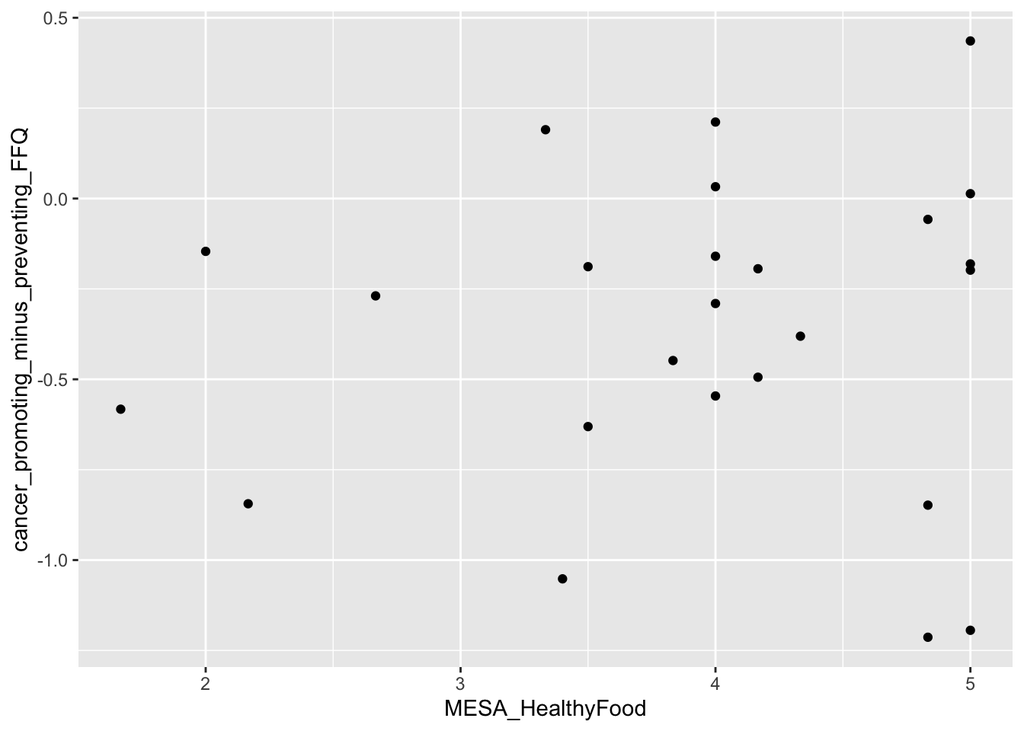

```r
ggplot(dv_iv_data,aes_string(x=IV,y=DV))+geom_point()
```